# Data Analysis Project

Both forms of analysis made us want to plot the top 50 songs by danceability and acousticness to see which ones seemed to be more consistent with our statistical findings. Acousticness has some peaks among the top 50, but overall, danceability seems to be consistently higher. Although acousticness has the highest correlation relative to other factors, it is too difficult to tell which attribute has the highest correlation while also being significant. If anything, the most newsworthy finding about this question may be about diversity when it comes to music taste, quality and popularity.

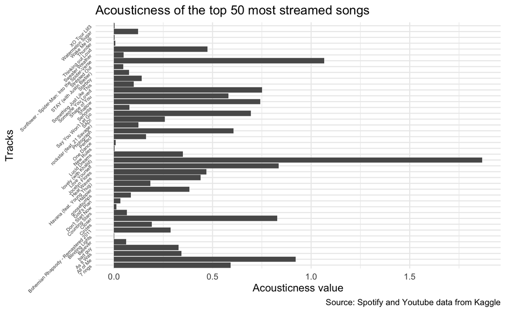

```r
attribute_correlate_stream <- spotify_youtube %>%
  select(danceability, energy, key, loudness, speechiness, acousticness, instrumentalness, liveness, valence, tempo, stream) %>%
  filter(complete.cases(.)) %>%

##Find the correlation coefficient between each attribute and number of Spotify streams
   mutate(
    dance_cor = cor(danceability, stream),
    energy_cor = cor(energy, stream),
    key_cor = cor(key, stream),
    speech_cor = cor(speechiness, stream),
    acoustic_cor = cor(acousticness, stream),
    instrumental_cor = cor(instrumentalness, stream),
    live_cor = cor(liveness, stream),
    valence_cor = cor(valence, stream),
    tempo_cor = cor(tempo, stream)
  ) %>%

##Find the mean correlation coefficient for each attribute
  summarise(
    mean_dance_cor = mean(dance_cor),
    mean_energy_cor = mean(energy_cor),
    mean_key_cor = mean(key_cor),
    mean_speech_cor = mean(speech_cor),
    mean_acoustic_cor = mean(acoustic_cor),
    mean_instrumental_cor = mean(instrumental_cor),
    mean_live_cor = mean(live_cor),
    mean_valence_cor = mean(valence_cor),
    mean_tempo_cor = mean(tempo_cor)
  )

##Output the highest value among the mean coefficients
max_value <- apply(attribute_correlate_stream, 1, max)

##Visualizations
spotify_youtube %>%
  arrange(desc(stream)) %>%
  head(50) %>%
  ggplot()+
  geom_bar(aes(x=track, weight=acousticness))+
  coord_flip()+
  theme_minimal()+
  labs(
    title = "Acousticness of the top 50 most streamed songs",
    x = "Tracks",
    y = "Acousticness value",
    caption = "Source: Spotify and Youtube data from Kaggle"
  )+
  theme(
      axis.text.y = element_text(angle = 45,  hjust=1, size=5)
    )
```

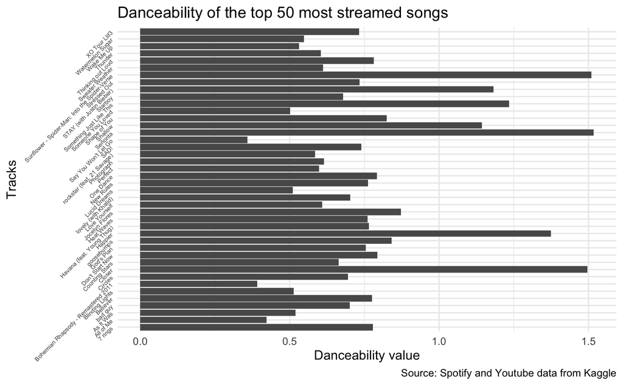

```r
spotify_youtube %>%
  arrange(desc(stream)) %>%
  head(50) %>%
  ggplot()+
  geom_bar(aes(x=track, weight=danceability))+
  coord_flip()+
  theme_minimal()+
  labs(
    title = "Danceability of the top 50 most streamed songs",
    x = "Tracks",
    y = "Danceability value",
    caption = "Source: Spotify and Youtube data from Kaggle"
  )+
  theme(
      axis.text.y = element_text(angle = 45,  hjust=1, size=5)
    )
```

**Question 2: Does higher engagement on YouTube videos lead to more streams of the song from the video on Spotify? Is there a relationship that exists between social engagement and streams?**

**Question 3: How many videos with a high number of streams are coming from licensed content?**